# Comcast Complaint Analysis Project

Comcast is an American global telecommunication company. The firm has been providing terrible customer service. They continue to fall short despite repeated promises to improve. Only last month (October 2016) the authority fined them a $2.3 million, after receiving over 1000 consumer complaints. The existing database will serve as a repository of public customer complaints filed against Comcast. It will help to pin down what is wrong with Comcast’s customer service

Task Need to be performed:

• Importing data into R environment.

• Provide the trend chart for the number of complaints at monthly and daily granularity levels.

• Provide a table with the frequency of complaint types. -Which complaint types are maximum i.e., around internet, network issues, or across any other domains.

• Create a new categorical variable with value as Open and Closed. Open & Pending is to be categorized as Open and Closed & Solved is to be categorized as Closed

• Provide state wise status of complaints in a stacked bar chart. Use the categorized variable from Q3.

• Provide insights on: -Which state has the maximum complaints -Which state has the highest percentage of unresolved complaints

• Provide the percentage of complaints resolved till date, which were received through the Internet and customer care calls.

## Libraries used in the project

```python
import numpy as np #Numpy library for doing mathematical Operations
import pandas as pd #Pandas library for doing Data Wrangling
import matplotlib.pyplot as plt # Mathplotlib for Visualizations
import seaborn as sns # Seaborn library for Statasticals visualizations
from datetime import datetime
```

## Import data into Python environment.

```python
comcast=pd.read_csv("Comcast_telecom_complaints_data.csv",sep=",")
#Imported the "Comcast Telecom Complaints data.csv" file from windows explorer.
```

## Handling missing values.

```python
comcast.info()
# we can see that there is total 2224 non-null values on all the columns so there is no missing data in the dataset.
```

```
<class 'pandas.core.frame.DataFrame'>
RangeIndex: 2224 entries, 0 to 2223
Data columns (total 11 columns):
 #   Column                       Non-Null Count  Dtype
---  ------                       --------------  -----
 0   Ticket #                     2224 non-null   object
 1   Customer Complaint           2224 non-null   object
 2   Date                         2224 non-null   object
 3   Date_month_year              2224 non-null   object
 4   Time                         2224 non-null   object
 5   Received Via                 2224 non-null   object
 6   City                         2224 non-null   object
 7   State                        2224 non-null   object
 8   Zip code                     2224 non-null   int64
 9   Status                       2224 non-null   object
 10  Filing on Behalf of Someone  2224 non-null   object
dtypes: int64(1), object(10)
memory usage: 191.2+ KB
```

## Cleaning the Date Column

```python
comcast["Date_month_year"]=pd.to_datetime(comcast["Date_month_year"])
comcast['Month']=comcast["Date_month_year"].dt.month
```

## Provide the trend chart for the number of complaints at monthly and daily granularity levels.

```python
Monthly_count=pd.DataFrame(comcast['Month'].value_counts())
Monthly_count=Monthly_count.reset_index().sort_values("index")
Monthly_count.columns
Monthly_count.rename(columns={'index':'Month','Month':'Count'},inplace=True)
Monthly_count
```

|  | Month | Count |
| --- | --- | --- |
| 7 | 1 | 55 |
| 5 | 2 | 59 |
| 10 | 3 | 45 |
| 1 | 4 | 375 |
| 2 | 5 | 317 |
| 0 | 6 | 1046 |
| 9 | 7 | 49 |
| 3 | 8 | 67 |
| 6 | 9 | 55 |
| 8 | 10 | 53 |
| 11 | 11 | 38 |
| 4 | 12 | 65 |

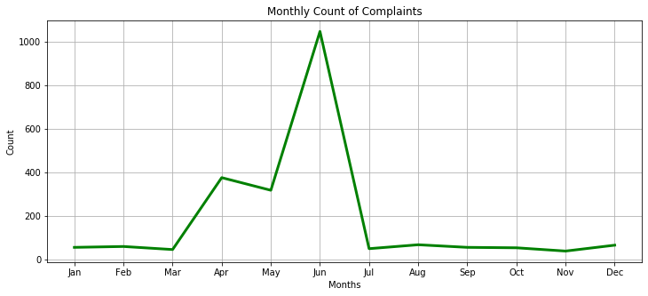

```python
month_name=['Jan','Feb','Mar','Apr','May','Jun','Jul','Aug','Sep','Oct','Nov','Dec']
plt.xlabel('Months')
plt.xticks(Monthly_count["Month"],month_name)
plt.ylabel('Count')
plt.title('Monthly Count of Complaints')
plt.plot(Monthly_count["Month"],Monthly_count["Count"],linewidth=3, color='green')
plt.grid()
plt.rcParams['figure.figsize']={12,5}
```

```python
Daily_count=pd.DataFrame(comcast['Date_month_year'].value_counts())
Daily_count=Daily_count.reset_index().sort_values('index')
Daily_count.columns
Daily_count.rename(columns={'index':'Days','Date_month_year':'Count'},inplace=True)
Daily_count
```

|  | Days | Count |
| --- | --- | --- |
| 43 | 2015-01-04 | 18 |
| 66 | 2015-01-05 | 12 |
| 25 | 2015-01-06 | 25 |
| 17 | 2015-02-04 | 27 |
| 85 | 2015-02-05 | 7 |
| ... | ... | ... |
| 71 | 2015-11-05 | 12 |
| 38 | 2015-11-06 | 21 |
| 54 | 2015-12-04 | 15 |
| 87 | 2015-12-05 | 7 |
| 7 | 2015-12-06 | 43 |

91 rows × 2 columns

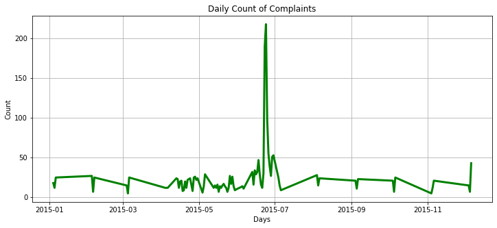

```python
plt.xlabel('Days')
plt.ylabel('Count')
plt.title('Daily Count of Complaints')
plt.plot(Daily_count["Days"],Daily_count["Count"],linewidth=3, color='green')
plt.grid()
plt.rcParams['figure.figsize']={30,40}
```

In the above plots, we can observe that there are maximum number tickets received in June month's second half.

## Provide a table with the frequency of complaint types. Which complaint types are maximum i.e., around internet, network issues, or across any other domains.

```python
comcast.head(3)
```

|  | Ticket # | Customer Complaint | Date | Date_month_year | Time | Received Via | City | State | Zip code | Status | Filing on Behalf of Someone | Month |
| --- | --- | --- | --- | --- | --- | --- | --- | --- | --- | --- | --- | --- |
| 0 | 250635 | Comcast Cable Internet Speeds | 22-04-15 | 2015-04-22 | 3:53:50 PM | Customer Care Call | Abingdon | Maryland | 21009 | Closed | No | 4 |
| 1 | 223441 | Payment disappear - service got disconnected | 04-08-15 | 2015-08-04 | 10:22:56 AM | Internet | Acworth | Georgia | 30102 | Closed | No | 8 |
| 2 | 242732 | Speed and Service | 18-04-15 | 2015-04-18 | 9:55:47 AM | Internet | Acworth | Georgia | 30101 | Closed | Yes | 4 |

```python
comcast["Customer Complaint"]=comcast["Customer Complaint"].str.lower()
```

```python
# To be remove warnings
import warnings
warnings.filterwarnings(action="ignore")
```

```python
comcast["Comp_types"]=""
z=comcast["Customer Complaint"].str.contains('internet',)
y=comcast["Customer Complaint"].str.contains('service')
x=comcast["Customer Complaint"].str.contains('bill')
u=comcast["Customer Complaint"].str.contains('email')
v=comcast["Customer Complaint"].str.contains('network')
comcast.Comp_types[z]="Internet"
comcast.Comp_types[y]="Service"
comcast.Comp_types[x]="Bill"
comcast.Comp_types[u]="E-Mail"
comcast.Comp_types[v]="Network"
Comp_Types=pd.DataFrame(comcast.Comp_types.value_counts())
Comp_Types.reset_index(inplace=True)
Comp_Types.columns=['Complaint_Type','Count']
s=Comp_Types["Complaint_Type"].str.contains(' ')
Comp_Types.Complaint_Type[0]="Others"
Comp_Types
```

|  | Complaint_Type | Count |
| --- | --- | --- |
| 0 | Others | 1065 |
| 1 | Service | 400 |
| 2 | Bill | 378 |
| 3 | Internet | 364 |
| 4 | E-Mail | 15 |
| 5 | Network | 2 |

After filtering various types of issues, we can observe that maximum number of issues falls under Service related category.

## Create a new categorical variable with value as Open and Closed. Open & Pending is to be categorized as Open and Closed & Solved is to be categorized as Closed

```python
comcast["NewStatus"] = ["Open" if Status=="Open" or Status=="Pending" else "Closed" for Status in comcast["Status"]]
comcast["NewStatus"].value_counts()
```

```
Closed    1707
Open       517
Name: NewStatus, dtype: int64
```

Created a new variable with name New_Status and simplified the ticket status into two categories "Open" and "Closed"

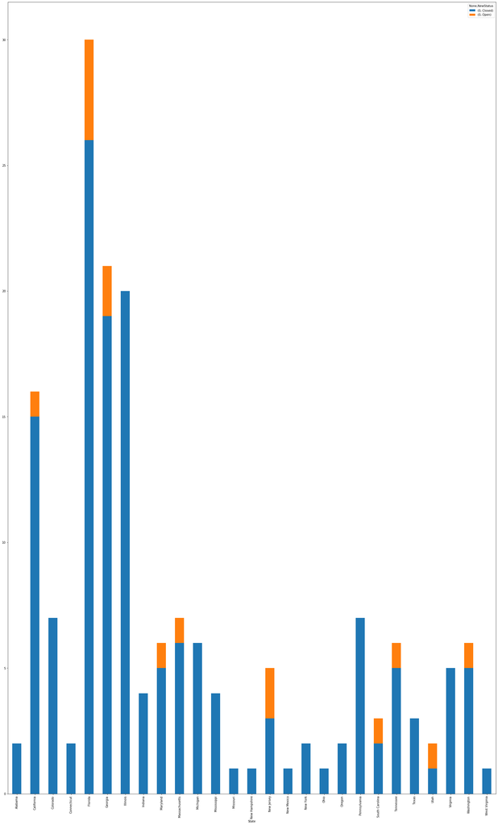

```python
a=comcast.groupby(["State","Month","NewStatus"]).size().sort_values(ascending=False).reset_index()
a=a[(a['Month']>6)&(a['Month']<10)].drop("Month",axis=1)
a=a.groupby(["State","NewStatus"]).sum().unstack().fillna(0)
a.plot(kind="bar", figsize=(30,50), stacked=True)
plt.rcParams['figure.figsize']={.1,.07}
```

## Provide insights on: -Which state has the maximum complaints -Which state has the highest percentage of unresolved complaints

```python
#Which state has the maximum complaints
comcast.groupby(["State"]).size().sort_values(ascending=False).to_frame().reset_index().rename({0: "Count"}, axis=1)[:5]
```

|  | State | Count |
| --- | --- | --- |
| 0 | Georgia | 288 |
| 1 | Florida | 240 |
| 2 | California | 220 |
| 3 | Illinois | 164 |
| 4 | Tennessee | 143 |

From the above table we can see that Georgia is haaving the maximum complaints with count if 288

```python
Count=comcast[comcast.NewStatus=="Open"].groupby(["State"]).size().sort_values(ascending=False).to_frame().rename({0: "Count"}, axis=1)
Count["Percentage"]=(Count["Count"]/len(comcast.NewStatus))*100
Count.head(3)
```

| State | Count | Percentage |
| --- | --- | --- |
| Georgia | 80 | 3.597122 |
| California | 61 | 2.742806 |
| Tennessee | 47 | 2.113309 |

## Provide the percentage of complaints resolved till date, which were received through the Internet and customer care calls.

```python
Count=comcast[comcast.NewStatus=="Closed"].groupby(['Received Via','NewStatus']).size().sort_values(ascending=False).to_frame().rename({0: "Count"}, axis=1).reset_index()
Count["Percentage"]=(Count["Count"]/len(comcast.NewStatus))*100
Count
```

|  | Received Via | NewStatus | Count | Percentage |
| --- | --- | --- | --- | --- |
| 0 | Customer Care Call | Closed | 864 | 38.848921 |
| 1 | Internet | Closed | 843 | 37.904676 |

From the Above Table we can tell the below Observations

- Percentage of resolved complaints received through Internet = 37.9
- Percentage of resolved complaints received through Customer Care Call = 38.8